# Does dietary information improve classification of prevalent dental caries?

An independent survey-weighted analysis of ENS 2016–17

## 1 Question and principal finding

This independent analysis asks whether **15 dietary intake constructs improve classification of existing cavitated caries beyond 17 contextual predictors**. Six behaviours concerning food labels are assessed separately. A second information scenario adds six concurrent oral symptoms and self-ratings. The analysis is an exploratory, dataset-informed extension; its specification was fixed before these new fits after earlier work on the same survey.

**5,036**Dentate participants evaluated in every variant

**15**Dietary constructs in the primary incremental comparison

**54.6%**Survey-weighted prevalence of cavitated caries

**Primary result.** Spline logistic regression changed from a Brier score of 0.2335 with C17 to 0.2379 with C17+D15. The paired Brier gain was **-0.004395 (-0.007161 to -0.001617)**, corresponding to a 1.88% relative increase in the reference Brier score. The AUC gain was -0.0144 (-0.0273 to -0.0014) and the log-loss gain was -0.010160 (-0.016081 to -0.004214). All intervals are conditional 95% survey-bootstrap intervals.

**Interpretation.** Adding the measured dietary block worsened probability accuracy in the primary analysis; these results do not support its proposed incremental benefit under this specification.

AUC describes ranking, while Brier score evaluates the accuracy of predicted probabilities. AUC 0.5 is a chance-ranking reference; an AUC above that value does not by itself establish useful individual predictions. The primary question is the paired gain from dietary information, with calibration and absolute performance providing context. No model family is promoted to primary because it has the largest observed AUC.

## 2 Population, measurements and information sets

The source is the ENS 2016–17 SPSS release. Participants were eligible if both jaw counts were observed and at least one tooth remained. The outcome is at least one clinically observed decayed tooth. Missing examinations are not treated as caries-free. All eligible participants retain their place in validation despite predictor missingness; outcomes are never imputed.

Population and outcome completeness.

| Population step | Unweighted count |
| --- | --- |
| Survey records | 6233 |
| Complete dental examinations | 5520 |
| Edentulous participants | 484 |
| Dentate eligible participants | 5036 |
| Caries cases | 2689 |
| Participants without caries | 2347 |
| Missing outcomes among eligible participants | 0 |

Declared information blocks.

| Block | Constructs | Content |
| --- | --- | --- |
| B8 | 8 | Age, sex, region, residence, education, indigenous identification, birthplace and remaining teeth |
| C17 | 17 | B8 plus household income, health insurance, smoking, reported diabetes, dental attendance/reason/access and two water-context variables |
| D15 | 15 | Fish, dairy frequency/type, wholegrain, legumes, fruit and vegetable days/portions, water, soda/juice frequencies and volumes, cooking fat |
| L6 | 6 | Attention to ingredients, nutrition, warnings, health information, brand and discounts |
| S6 | 6 | Self-rated oral health, pain and interference with speaking, eating, daily activities and social relationships |

C17, D15, L6 and S6 are disjoint. B8 is a subset of C17. Labels are behaviours concerning packaging, not direct measures of food consumption.

Household income is grouped into the questionnaire’s 11 fixed bands, using the exact reported amount when available and the supplied band otherwise. No monetary midpoint is invented. “Never visited a dentist” is a structural category; an unknown visit reason stays missing. A positive diabetes code meaning “does not remember” is missing. Dental-access “not applicable” is not interpreted as absence of need.

Soda and juice volumes are standard glasses per day, calculated from frequency and glasses per occasion. They are not grams of sugar. Frequencies use seven days per week and 30 days per month. All four beverage frequency/volume fields undergo `log1p` in the model pipeline. Valid zeros and the original extreme observations are retained in the primary analysis. Water remains reported glasses per day, with no inferred fluoride exposure.

Selected quantitative characteristics by caries status.

| Measure | Units | No caries | Caries | Total |
| --- | --- | --- | --- | --- |
| Age at survey | years | 39.72 (38.51 to 40.92); n=2,347 | 43.38 (42.44 to 44.32); n=2,689 | 41.72 (40.92 to 42.51); n=5,036 |
| Total remaining teeth, upper plus lower jaw | teeth | 24.45 (24.01 to 24.88); n=2,347 | 23.08 (22.67 to 23.50); n=2,689 | 23.70 (23.39 to 24.01); n=5,036 |
| Self-reported glasses of water per day; water source/fluoride exposure not identified | glasses/day | 4.31 (4.08 to 4.53); n=2,346 | 4.13 (3.92 to 4.35); n=2,686 | 4.21 (4.05 to 4.38); n=5,032 |
| Sugar-sweetened soda consumption frequency converted to times/day | times/day | 0.73 (0.62 to 0.83); n=2,347 | 0.91 (0.76 to 1.05); n=2,689 | 0.83 (0.73 to 0.92); n=5,036 |
| Sugar-sweetened juice consumption frequency converted to times/day | times/day | 0.63 (0.52 to 0.73); n=2,347 | 0.70 (0.58 to 0.81); n=2,689 | 0.67 (0.59 to 0.75); n=5,036 |
| Estimated daily soda volume in glasses; extreme reported values retained and audited | glasses/day | 2.37 (1.63 to 3.11); n=2,345 | 3.11 (2.12 to 4.10); n=2,688 | 2.77 (2.13 to 3.42); n=5,033 |
| Estimated daily juice volume in glasses; extreme reported values retained and audited | glasses/day | 1.51 (1.21 to 1.82); n=2,346 | 1.93 (1.45 to 2.40); n=2,688 | 1.74 (1.45 to 2.03); n=5,034 |

Survey-weighted mean (95% design-based CI); n is the unweighted observed denominator. Quantities are shown on their original scale. The complete 44-construct profile and missingness appear below; these descriptive comparisons do not select predictors.

## 3 Development and evaluation

Each of seven information sets was fitted using penalized spline logistic regression, random forest and histogram gradient boosting, producing 21 main variants. Spline logistic regression was the primary family. Two separately tuned spline variants assessed beverage extremes. An intercept-only benchmark uses the weighted caries prevalence in each outer training partition.

All variants share five outer validation folds, with three inner folds for tuning. Survey PSUs stay intact in both layers. Imputation, category vocabularies, scaling, spline knots and sensitivity cutoffs are learned only from the respective training partition. Numeric missingness indicators accompany training-median imputation. Categorical missing responses form an explicit level; unseen validation categories are handled by the fitted encoder. The same participant receives one held-out probability from each variant.

The candidate grids were fixed before these new fits and inherited earlier methodological development on this dataset. Inner pooled survey-weighted log loss selects parameters. All fitted estimators receive training weights normalized to mean one. Splines with three training-derived quantile knots model age, remaining teeth and water; other numeric terms, including transformed beverages, enter linearly in the spline logistic family. There is no class balancing, oversampling or outer-test-based threshold selection.

Development specifications.

| Family | Fixed search space |
| --- | --- |
| Spline logistic | C: 0.0001, 0.001, 0.01, 0.1, 1, 10; L2 regularization; up to 3000 iterations |
| Random forest | 200 trees; minimum leaf size 5, 20, 50, 100 × maximum features sqrt or 0.7 |
| Histogram boosting | Maximum leaves 3, 7, 15 × L2 regularization 1, 10, 100; 150 iterations; no early stopping |

**Survey-weight status.** Working examination-phase weight; official manual confirmation outstanding. The supplied weight is `Fexp_F1F2p_Corr`, numerically identical to `Fexp_F2p_Corr` in this release.

Performance is evaluated from held-out probabilities using survey weights. The primary gain is **Brier(C17) − Brier(C17+D15)** for spline logistic regression. AUC gain is expanded minus reference AUC, while log-loss gain is reference minus expanded log loss: positive values consistently favour the added information. Relative loss reduction divides the absolute gain by the reference loss.

The 1000 paired, rescaled PSU-bootstrap replicates are shared across models and retain the full positive-weight sampling design before subsetting to the dentate domain. They condition on the fitted models, selected parameters and validation folds; they do not capture repeating the entire development process or transport to another population. Singleton strata remain fixed in this bootstrap. Descriptive tables instead use ratio linearization, design-t intervals and the average-stratum variance convention for singleton strata. The two variance conventions are disclosed because neither recovers otherwise unidentified within-singleton variation.

## 4 Absolute performance

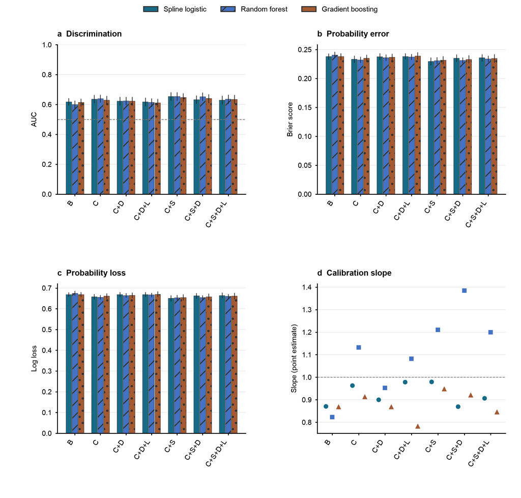

Performance of 21 newly developed model variants in 5,036 dentate participants. B, eight basic predictors; C, 17 context predictors; D, 15 direct-consumption indicators; L, six label behaviours; S, six concurrent oral-status indicators. Panels a–c show survey-weighted held-out estimates and conditional 95% intervals from 1,000 shared stratified PSU-bootstrap draws. Bars begin at zero. Panel d shows calibration-slope point estimates without confidence intervals. Dashed references are AUC 0.5 and calibration slope 1. Higher AUC, lower probability losses and slopes near one are desirable. No model is selected from these outer-validation results.

Performance of the 21 main variants.

| Model and information set | AUC (95% CI) | Brier (95% CI) | Log loss (95% CI) |
| --- | --- | --- | --- |
| Spline logistic: B8 | 0.618 (0.594 to 0.643) | 0.2380 (0.2328 to 0.2431) | 0.6687 (0.6578 to 0.6796) |
| Random forest: B8 | 0.601 (0.573 to 0.627) | 0.2407 (0.2357 to 0.2461) | 0.6747 (0.6641 to 0.6860) |
| Histogram boosting: B8 | 0.615 (0.587 to 0.640) | 0.2380 (0.2324 to 0.2435) | 0.6686 (0.6568 to 0.6802) |
| Spline logistic: C17 | 0.637 (0.609 to 0.664) | 0.2335 (0.2272 to 0.2395) | 0.6585 (0.6452 to 0.6711) |
| Random forest: C17 | 0.640 (0.613 to 0.666) | 0.2324 (0.2272 to 0.2377) | 0.6561 (0.6447 to 0.6671) |
| Histogram boosting: C17 | 0.630 (0.602 to 0.657) | 0.2351 (0.2289 to 0.2413) | 0.6621 (0.6489 to 0.6752) |
| Spline logistic: C17+D15 | 0.623 (0.594 to 0.651) | 0.2379 (0.2323 to 0.2436) | 0.6686 (0.6568 to 0.6808) |
| Random forest: C17+D15 | 0.625 (0.596 to 0.651) | 0.2361 (0.2307 to 0.2416) | 0.6644 (0.6529 to 0.6761) |
| Histogram boosting: C17+D15 | 0.623 (0.594 to 0.651) | 0.2368 (0.2304 to 0.2427) | 0.6657 (0.6521 to 0.6784) |
| Spline logistic: C17+D15+L6 | 0.618 (0.590 to 0.647) | 0.2383 (0.2330 to 0.2437) | 0.6691 (0.6581 to 0.6805) |
| Random forest: C17+D15+L6 | 0.614 (0.585 to 0.642) | 0.2375 (0.2324 to 0.2424) | 0.6672 (0.6562 to 0.6773) |
| Histogram boosting: C17+D15+L6 | 0.612 (0.583 to 0.639) | 0.2391 (0.2328 to 0.2452) | 0.6705 (0.6571 to 0.6839) |
| Spline logistic: C17+S6 | 0.654 (0.626 to 0.683) | 0.2298 (0.2229 to 0.2365) | 0.6506 (0.6358 to 0.6650) |
| Random forest: C17+S6 | 0.654 (0.625 to 0.683) | 0.2310 (0.2250 to 0.2368) | 0.6538 (0.6411 to 0.6660) |
| Histogram boosting: C17+S6 | 0.647 (0.617 to 0.675) | 0.2317 (0.2248 to 0.2386) | 0.6550 (0.6402 to 0.6696) |
| Spline logistic: C17+S6+D15 | 0.633 (0.606 to 0.661) | 0.2352 (0.2287 to 0.2416) | 0.6627 (0.6488 to 0.6765) |
| Random forest: C17+S6+D15 | 0.653 (0.624 to 0.681) | 0.2315 (0.2263 to 0.2365) | 0.6549 (0.6438 to 0.6652) |
| Histogram boosting: C17+S6+D15 | 0.641 (0.610 to 0.669) | 0.2331 (0.2262 to 0.2403) | 0.6581 (0.6432 to 0.6737) |
| Spline logistic: C17+S6+D15+L6 | 0.630 (0.601 to 0.659) | 0.2360 (0.2299 to 0.2422) | 0.6646 (0.6514 to 0.6779) |
| Random forest: C17+S6+D15+L6 | 0.637 (0.605 to 0.666) | 0.2341 (0.2287 to 0.2395) | 0.6602 (0.6489 to 0.6716) |
| Histogram boosting: C17+S6+D15+L6 | 0.635 (0.605 to 0.664) | 0.2347 (0.2275 to 0.2420) | 0.6619 (0.6462 to 0.6772) |

AUC is better when higher; Brier score and log loss are better when lower. Intervals condition on the fitted nested-validation models. Every row uses the same eligible participants.

Training-fold prevalence benchmark.

| Model and information set | AUC (95% CI) | Brier (95% CI) | Log loss (95% CI) |
| --- | --- | --- | --- |
| Training-fold prevalence benchmark | 0.477 (0.445 to 0.506) | 0.2481 (0.2457 to 0.2505) | 0.6893 (0.6844 to 0.6942) |

Each fold receives a probability estimated from its training participants only. The pooled calibration slope of this within-fold constant benchmark is not interpreted.

## 5 Incremental contribution of diet

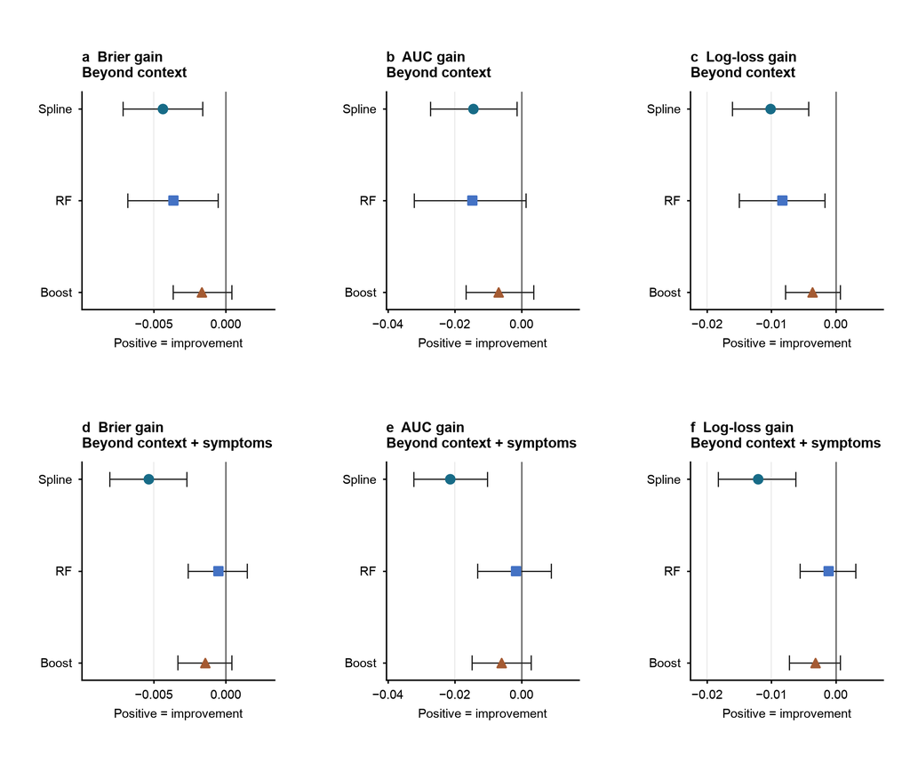

Incremental contribution of the 15 direct dietary indicators beyond context (a–c) and beyond context plus concurrent oral status (d–f). Brier and log-loss gains subtract the extended model loss from the reference loss; AUC gain subtracts reference AUC from extended AUC. Positive values uniformly favour adding diet. Whiskers are paired conditional 95% PSU-bootstrap intervals with shared draws. The spline Brier gain in panel a is the predeclared primary comparison for this dataset-informed extension; all other comparisons are complementary or exploratory. Zero-crossing intervals do not establish equivalence or the absence of a biological dietary role.

Paired dietary gains in both information scenarios.

| Comparison | Family | Brier gain (95% CI) | AUC gain (95% CI) | Log-loss gain (95% CI) |
| --- | --- | --- | --- | --- |
| Diet beyond context | Spline logistic | -0.004395 (-0.007161 to -0.001617) | -0.0144 (-0.0273 to -0.0014) | -0.010160 (-0.016081 to -0.004214) |
| Diet beyond context | Random forest | -0.003643 (-0.006822 to -0.000535) | -0.0147 (-0.0321 to 0.0013) | -0.008302 (-0.015001 to -0.001678) |
| Diet beyond context | Histogram boosting | -0.001662 (-0.003658 to 0.000407) | -0.0069 (-0.0167 to 0.0036) | -0.003606 (-0.007830 to 0.000663) |
| Diet beyond context and symptoms | Spline logistic | -0.005360 (-0.008082 to -0.002710) | -0.0214 (-0.0322 to -0.0103) | -0.012114 (-0.018292 to -0.006208) |
| Diet beyond context and symptoms | Random forest | -0.000502 (-0.002637 to 0.001474) | -0.0017 (-0.0132 to 0.0089) | -0.001091 (-0.005591 to 0.003087) |
| Diet beyond context and symptoms | Histogram boosting | -0.001431 (-0.003343 to 0.000415) | -0.0061 (-0.0148 to 0.0028) | -0.003192 (-0.007206 to 0.000694) |

Positive values indicate improvement. The spline C17+D15 versus C17 Brier contrast is primary. Other metrics, model families and symptom-conditioned comparisons are secondary exploratory analyses without multiplicity-adjusted confirmatory claims.

**Spline logistic.** Without S6, the Brier gain was -0.004395 (-0.007161 to -0.001617); the conditional interval favours the reference. With S6, it was -0.005360 (-0.008082 to -0.002710); the conditional interval favours the reference.

**Random forest.** Without S6, the Brier gain was -0.003643 (-0.006822 to -0.000535); the conditional interval favours the reference. With S6, it was -0.000502 (-0.002637 to 0.001474); the conditional interval includes no difference.

**Histogram boosting.** Without S6, the Brier gain was -0.001662 (-0.003658 to 0.000407); the conditional interval includes no difference. With S6, it was -0.001431 (-0.003343 to 0.000415); the conditional interval includes no difference.

An interval that includes zero does not establish equivalence. A favourable secondary estimate does not replace an unfavourable or imprecise primary finding. Differences in gain after adding symptoms describe different information scenarios; they do not identify mediation or a causal mechanism.

## 6 Separate contributions of label behaviours and context

Label-related behaviours beyond reported intake.

| Comparison | Family | Brier gain (95% CI) | AUC gain (95% CI) | Log-loss gain (95% CI) |
| --- | --- | --- | --- | --- |
| Label behaviours beyond context and diet | Spline logistic | -0.000377 (-0.002090 to 0.001361) | -0.0041 (-0.0124 to 0.0042) | -0.000499 (-0.004516 to 0.003319) |
| Label behaviours beyond context and diet | Random forest | -0.001418 (-0.003898 to 0.000872) | -0.0108 (-0.0242 to 0.0021) | -0.002740 (-0.008121 to 0.002036) |
| Label behaviours beyond context and diet | Histogram boosting | -0.002303 (-0.003683 to -0.001123) | -0.0113 (-0.0187 to -0.0051) | -0.004767 (-0.007577 to -0.002312) |
| Label behaviours beyond symptoms and diet | Spline logistic | -0.000839 (-0.002735 to 0.000845) | -0.0031 (-0.0107 to 0.0045) | -0.001913 (-0.006307 to 0.001818) |
| Label behaviours beyond symptoms and diet | Random forest | -0.002584 (-0.004640 to -0.000649) | -0.0161 (-0.0280 to -0.0048) | -0.005317 (-0.009675 to -0.001197) |
| Label behaviours beyond symptoms and diet | Histogram boosting | -0.001634 (-0.002932 to -0.000439) | -0.0061 (-0.0117 to -0.0008) | -0.003740 (-0.006585 to -0.001045) |

These six constructs are excluded from D15. They concern information-seeking and purchase considerations rather than direct food or nutrient quantities.

Expanded context and concurrent oral status.

| Comparison | Family | Brier gain (95% CI) | AUC gain (95% CI) | Log-loss gain (95% CI) |
| --- | --- | --- | --- | --- |
| Expanded context beyond basic | Spline logistic | 0.004491 (0.001102 to 0.008180) | 0.0186 (0.0026 to 0.0364) | 0.010212 (0.003119 to 0.018159) |
| Expanded context beyond basic | Random forest | 0.008248 (0.004386 to 0.012489) | 0.0391 (0.0170 to 0.0625) | 0.018546 (0.010441 to 0.027763) |
| Expanded context beyond basic | Histogram boosting | 0.002913 (-0.000660 to 0.006683) | 0.0149 (-0.0028 to 0.0335) | 0.006411 (-0.001254 to 0.014280) |
| Symptoms beyond context | Spline logistic | 0.003693 (0.000907 to 0.006296) | 0.0173 (0.0053 to 0.0292) | 0.007897 (0.002137 to 0.013469) |
| Symptoms beyond context | Random forest | 0.001469 (-0.001746 to 0.004493) | 0.0144 (-0.0037 to 0.0317) | 0.002341 (-0.004276 to 0.008505) |
| Symptoms beyond context | Histogram boosting | 0.003430 (0.000529 to 0.006375) | 0.0170 (0.0034 to 0.0312) | 0.007190 (0.001149 to 0.013382) |
| Symptoms beyond context, diet and labels | Spline logistic | 0.002264 (-0.000211 to 0.004573) | 0.0114 (0.0004 to 0.0226) | 0.004529 (-0.001090 to 0.009761) |
| Symptoms beyond context, diet and labels | Random forest | 0.003443 (0.000674 to 0.006217) | 0.0222 (0.0040 to 0.0393) | 0.006975 (0.001361 to 0.012728) |
| Symptoms beyond context, diet and labels | Histogram boosting | 0.004330 (0.001319 to 0.007182) | 0.0231 (0.0092 to 0.0365) | 0.008632 (0.002159 to 0.014843) |

Secondary exploratory comparisons. Dental symptoms and attendance may respond to existing disease or treatment; these contrasts are not causal effects.

## 7 Individual dietary and joint block contributions

Permutation contributions are evaluated only on held-out participants for the spline and random-forest C17+D15+L6 and C17+S6+D15+L6 fits. Each original construct is permuted before preprocessing, so its encoded levels and missingness information remain linked. Five repeats per outer fold are averaged within each fold and combined using held-out weight totals. The displayed minimum and maximum are the five fold means, **not confidence limits**.

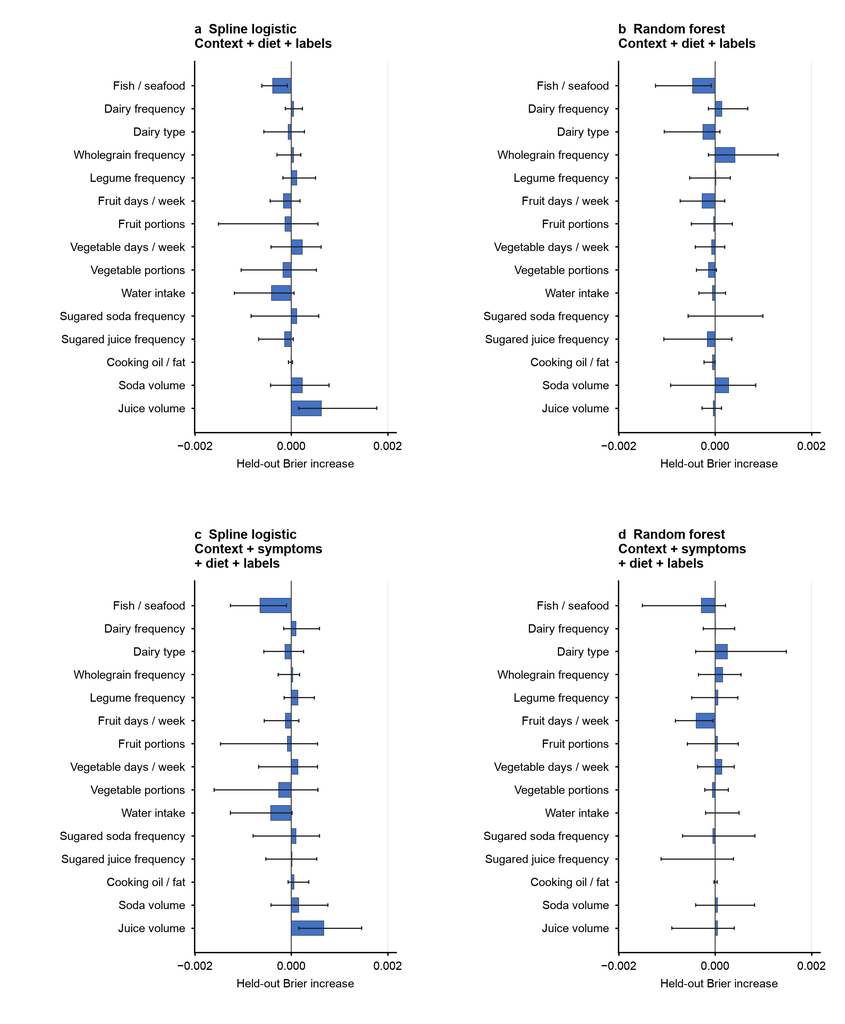

All 15 direct dietary indicators in questionnaire order, retaining the blue horizontal bars of the original manuscript. Panels a–b use the context, diet and label models; panels c–d add concurrent oral-status indicators. Each variable is permuted before the trained transformations, five times per held-out fold. Bars are weighted averages of fold mean Brier increases; whiskers are minimum–maximum fold means, not confidence intervals. The signed axis is shared across panels and negative values are retained. Frequency and volume indicators are dependent, so isolated-variable perturbations may create unusual combinations. These scores describe model reliance and do not establish causal direction, dietary effects or fractions of disease explained. Water remains explicitly displayed.

Sign and fold stability of all dietary contributions.

| Model | Dietary constructs shown | Positive mean ΔBrier | Negative mean ΔBrier | Fold range spans zero |
| --- | --- | --- | --- | --- |
| Spline logistic: C17+D15+L6 | 15 | 7 | 8 | 13 |
| Spline logistic: C17+S6+D15+L6 | 15 | 9 | 6 | 13 |
| Random forest: C17+D15+L6 | 15 | 4 | 11 | 14 |
| Random forest: C17+S6+D15+L6 | 15 | 9 | 6 | 14 |

These counts are descriptive, not significance tests. Negative contributions are retained. No diet variable is forced into a leading rank.

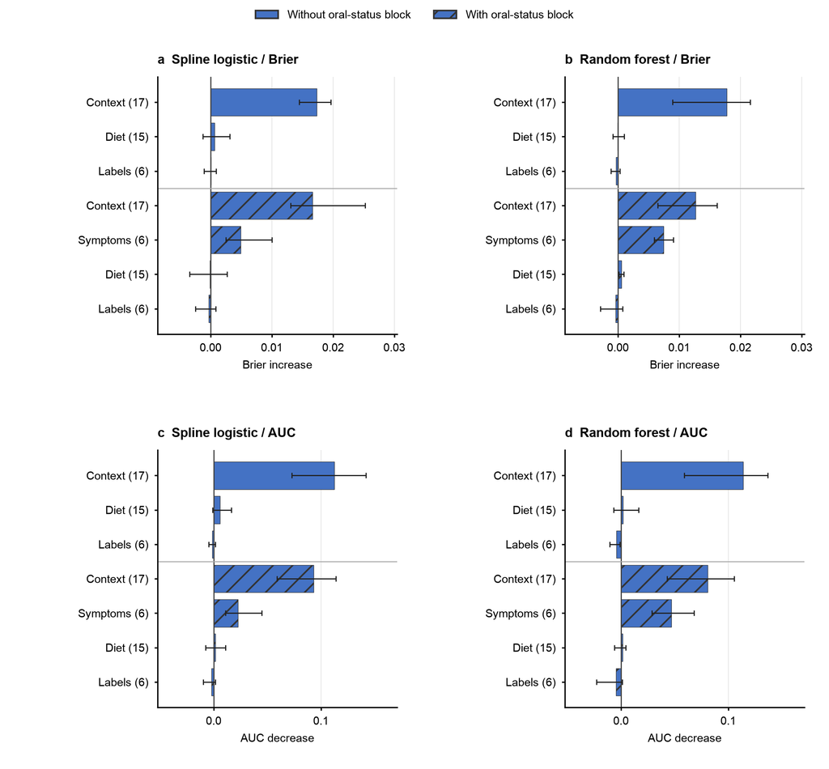

Joint permutation of complete predictor blocks in spline and random forest, shown as Brier increases (a–b) and AUC decreases (c–d). Unhatched bars correspond to C+D+L; hatched bars correspond to C+S+D+L. A single common donor permutation moves all raw variables in a block together, preserving their internal combinations. Counts of constructs are shown in labels. Bars combine fold means using held-out expansion totals; whiskers are minimum–maximum fold means and are not confidence intervals. Joint scores cannot be obtained by adding individual importances, and blocks of different sizes are not comparable percentages of explained disease. The refitted dietary comparison in Figure 2 addresses a different question.

Joint block permutation contributions.

| Model | Block | Mean ΔBrier | Fold minimum to maximum | Mean AUC decrease |
| --- | --- | --- | --- | --- |
| Random forest: C17+D15+L6 | context | 0.017787 | 0.008926 to 0.021590 | 0.1139 |
| Random forest: C17+D15+L6 | diet | -0.000088 | -0.000803 to 0.001049 | 0.0019 |
| Random forest: C17+D15+L6 | labels | -0.000296 | -0.001149 to 0.000348 | -0.0043 |
| Random forest: C17+S6+D15+L6 | context | 0.012673 | 0.006530 to 0.016217 | 0.0809 |
| Random forest: C17+S6+D15+L6 | diet | 0.000560 | 0.000158 to 0.000980 | 0.0016 |
| Random forest: C17+S6+D15+L6 | labels | -0.000353 | -0.002885 to 0.000773 | -0.0048 |
| Random forest: C17+S6+D15+L6 | symptoms | 0.007441 | 0.005901 to 0.009041 | 0.0469 |
| Spline logistic: C17+D15+L6 | context | 0.017355 | 0.014468 to 0.019625 | 0.1126 |
| Spline logistic: C17+D15+L6 | diet | 0.000672 | -0.001269 to 0.003104 | 0.0060 |
| Spline logistic: C17+D15+L6 | labels | 0.000091 | -0.001068 to 0.000900 | -0.0014 |
| Spline logistic: C17+S6+D15+L6 | context | 0.016630 | 0.013088 to 0.025248 | 0.0931 |
| Spline logistic: C17+S6+D15+L6 | diet | -0.000134 | -0.003436 to 0.002714 | 0.0017 |
| Spline logistic: C17+S6+D15+L6 | labels | -0.000288 | -0.002464 to 0.000820 | -0.0019 |
| Spline logistic: C17+S6+D15+L6 | symptoms | 0.004889 | 0.002493 to 0.010038 | 0.0227 |

All variables in a block share a donor-row permutation. Positive values indicate greater model reliance. Block sizes differ; joint importance is neither a sum of individual contributions nor the gain obtained by refitting a model with additional predictors.

Beverage frequencies and their derived volumes are dependent. Permuting one while retaining the other can generate implausible combinations and alter individual attribution. Joint D15 permutation preserves relationships within the dietary block, while the primary refitted comparison asks a different question about additional predictive information. Neither method measures dietary causation, protection, independent exposure effects or the percentage of caries explained.

## 8 Calibration, beverage sensitivity and subgroups

The tail sensitivity caps each beverage variable at the 99th percentile among strictly positive observations in the relevant training partition before `log1p`. The percentile is unweighted and uses linear interpolation. Zeros and missing values are retained. When there are no positive training observations, no cap is estimable and only the logarithmic transformation is applied. These variants are independently tuned using the same inner-fold grid.

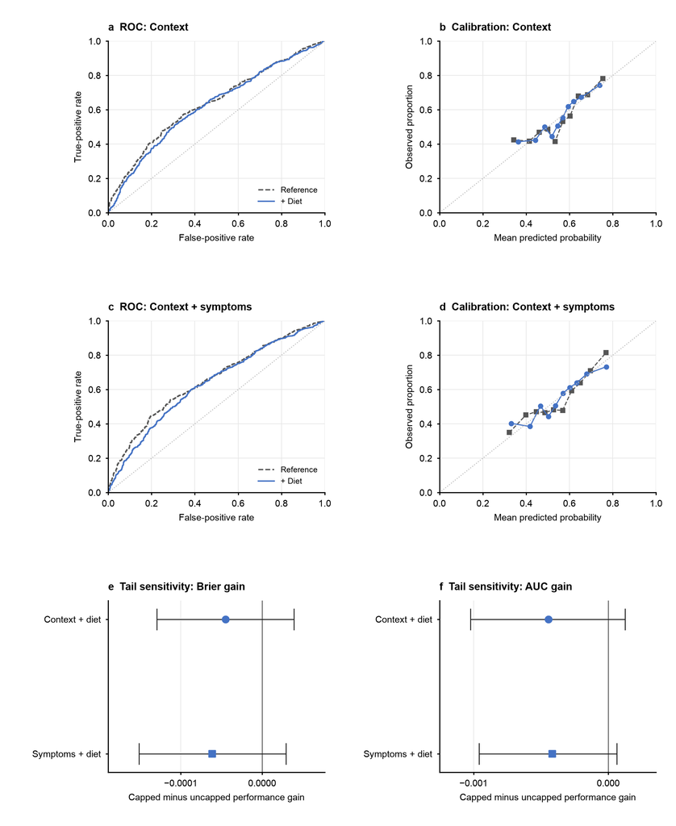

Validation of the primary spline information scenarios: ROC and binned calibration without oral status (a–b), and with oral status (c–d). Calibration bins summarize held-out predictions and do not have confidence intervals. Panels e–f compare the two additional spline sensitivities with their corresponding uncapped diet models. Sensitivities cap each beverage frequency/volume at its 99th percentile among positive training values before log1p; the cutoff and all other transformations are learned within each inner training set and outer refit. Paired conditional 95% intervals use the same 1,000 PSU-bootstrap draws. Positive gains favour the sensitivity. Neither validation display is an independent external validation.

Training-positive-p99 beverage sensitivity variants.

| Model and information set | AUC (95% CI) | Brier (95% CI) | Log loss (95% CI) |
| --- | --- | --- | --- |
| Spline logistic: C17+D15; positive-p99 sensitivity | 0.622 (0.594 to 0.651) | 0.2379 (0.2324 to 0.2437) | 0.6687 (0.6569 to 0.6808) |
| Spline logistic: C17+S6+D15; positive-p99 sensitivity | 0.632 (0.605 to 0.661) | 0.2352 (0.2288 to 0.2416) | 0.6628 (0.6490 to 0.6766) |

Capped versus corresponding uncapped spline models.

| Comparison | Family | Brier gain (95% CI) | AUC gain (95% CI) | Log-loss gain (95% CI) |
| --- | --- | --- | --- | --- |
| Training-positive-p99 beverage sensitivity | Spline logistic | -0.000045 (-0.000129 to 0.000039) | -0.0004 (-0.0010 to 0.0001) | -0.000080 (-0.000257 to 0.000103) |
| Training-positive-p99 beverage sensitivity | Spline logistic | -0.000061 (-0.000151 to 0.000029) | -0.0004 (-0.0010 to 0.0001) | -0.000113 (-0.000304 to 0.000086) |

These paired contrasts concern the handling of extreme beverage reports. They do not validate the original units or establish a biological threshold.

Calibration of the primary information scenarios.

| Model | Calibration-in-the-large | Calibration slope | Status |
| --- | --- | --- | --- |
| Spline logistic: C17 | -0.001 | 0.964 | Estimated |
| Spline logistic: C17+D15 | -0.002 | 0.900 | Estimated |
| Spline logistic: C17+S6 | -0.000 | 0.980 | Estimated |
| Spline logistic: C17+S6+D15 | -0.008 | 0.870 | Estimated |

Intercept target 0 and slope target 1. These pooled held-out calibration estimates and curves are descriptive; no separate confidence intervals were calculated for them.

Descriptive survey-weighted subgroup performance.

| Model | Subgroup | Level | n | Cases | AUC | Brier |
| --- | --- | --- | --- | --- | --- | --- |
| Spline logistic: C17 | sex | Female | 3125 | 1579 | 0.610 | 0.2409 |
| Spline logistic: C17 | sex | Male | 1911 | 1110 | 0.654 | 0.2261 |
| Spline logistic: C17 | age_group | 15–24 | 729 | 280 | 0.547 | 0.2412 |
| Spline logistic: C17 | age_group | 25–44 | 1569 | 828 | 0.583 | 0.2418 |
| Spline logistic: C17 | age_group | 45–64 | 1759 | 1034 | 0.682 | 0.2209 |
| Spline logistic: C17 | age_group | 65+ | 979 | 547 | 0.680 | 0.2245 |
| Spline logistic: C17 | rural | Rural | 760 | 431 | 0.646 | 0.2316 |
| Spline logistic: C17 | rural | Urban | 4276 | 2258 | 0.635 | 0.2337 |
| Spline logistic: C17 | education | High | 1179 | 525 | 0.579 | 0.2437 |
| Spline logistic: C17 | education | Intermediate | 2811 | 1536 | 0.646 | 0.2301 |
| Spline logistic: C17 | education | Low | 1008 | 606 | 0.636 | 0.2269 |
| Spline logistic: C17+D15 | sex | Female | 3125 | 1579 | 0.590 | 0.2452 |
| Spline logistic: C17+D15 | sex | Male | 1911 | 1110 | 0.643 | 0.2306 |
| Spline logistic: C17+D15 | age_group | 15–24 | 729 | 280 | 0.546 | 0.2435 |
| Spline logistic: C17+D15 | age_group | 25–44 | 1569 | 828 | 0.579 | 0.2427 |
| Spline logistic: C17+D15 | age_group | 45–64 | 1759 | 1034 | 0.632 | 0.2308 |
| Spline logistic: C17+D15 | age_group | 65+ | 979 | 547 | 0.654 | 0.2299 |
| Spline logistic: C17+D15 | rural | Rural | 760 | 431 | 0.641 | 0.2330 |
| Spline logistic: C17+D15 | rural | Urban | 4276 | 2258 | 0.620 | 0.2385 |
| Spline logistic: C17+D15 | education | High | 1179 | 525 | 0.565 | 0.2471 |
| Spline logistic: C17+D15 | education | Intermediate | 2811 | 1536 | 0.631 | 0.2343 |
| Spline logistic: C17+D15 | education | Low | 1008 | 606 | 0.600 | 0.2350 |
| Spline logistic: C17+S6 | sex | Female | 3125 | 1579 | 0.635 | 0.2363 |
| Spline logistic: C17+S6 | sex | Male | 1911 | 1110 | 0.665 | 0.2234 |
| Spline logistic: C17+S6 | age_group | 15–24 | 729 | 280 | 0.589 | 0.2358 |
| Spline logistic: C17+S6 | age_group | 25–44 | 1569 | 828 | 0.608 | 0.2380 |
| Spline logistic: C17+S6 | age_group | 45–64 | 1759 | 1034 | 0.688 | 0.2189 |
| Spline logistic: C17+S6 | age_group | 65+ | 979 | 547 | 0.697 | 0.2196 |
| Spline logistic: C17+S6 | rural | Rural | 760 | 431 | 0.654 | 0.2301 |
| Spline logistic: C17+S6 | rural | Urban | 4276 | 2258 | 0.654 | 0.2298 |
| Spline logistic: C17+S6 | education | High | 1179 | 525 | 0.614 | 0.2376 |
| Spline logistic: C17+S6 | education | Intermediate | 2811 | 1536 | 0.656 | 0.2278 |
| Spline logistic: C17+S6 | education | Low | 1008 | 606 | 0.660 | 0.2232 |
| Spline logistic: C17+S6+D15 | sex | Female | 3125 | 1579 | 0.613 | 0.2411 |
| Spline logistic: C17+S6+D15 | sex | Male | 1911 | 1110 | 0.643 | 0.2293 |
| Spline logistic: C17+S6+D15 | age_group | 15–24 | 729 | 280 | 0.563 | 0.2409 |
| Spline logistic: C17+S6+D15 | age_group | 25–44 | 1569 | 828 | 0.590 | 0.2416 |
| Spline logistic: C17+S6+D15 | age_group | 45–64 | 1759 | 1034 | 0.642 | 0.2276 |
| Spline logistic: C17+S6+D15 | age_group | 65+ | 979 | 547 | 0.683 | 0.2223 |
| Spline logistic: C17+S6+D15 | rural | Rural | 760 | 431 | 0.621 | 0.2377 |
| Spline logistic: C17+S6+D15 | rural | Urban | 4276 | 2258 | 0.633 | 0.2349 |
| Spline logistic: C17+S6+D15 | education | High | 1179 | 525 | 0.590 | 0.2433 |
| Spline logistic: C17+S6+D15 | education | Intermediate | 2811 | 1536 | 0.635 | 0.2327 |
| Spline logistic: C17+S6+D15 | education | Low | 1008 | 606 | 0.621 | 0.2300 |

Subgroups are sex, age, residence and observed education. No subgroup intervals, interaction tests or heterogeneity claims are supplied; missing education is not an observed education category.

## 9 Interpretation and limits

Adding the measured dietary block worsened probability accuracy in the primary analysis; these results do not support its proposed incremental benefit under this specification.

The primary dietary comparison changed AUC from 0.637 to 0.623, with a paired gain of -0.0144 (-0.0273 to -0.0014). Absolute discrimination and calibration must therefore be considered alongside the signed probability-score gain; the analysis does not establish a threshold for clinical decisions or clinical net benefit.

The dietary questionnaire measures broad consumption habits and beverage reports. It contains no verified brushing, toothpaste/fluoride, floss or xerostomia variables. Water quantity and supply do not measure individual fluoride exposure. Measurement error, sparse consumption categories and correlated predictors can limit the information available to the models. Adding more variables cannot guarantee improved predictions.

This is classification of caries present at examination, not prediction of future lesions. S6 may encode consequences of current disease or denture problems; attendance, treatment and access in C17 may also respond to disease. The context set already includes a tooth count, so these results do not establish a questionnaire-only remote screening tool. Medication classes and laboratory markers were not added merely to maximize AUC.

The same dataset informed earlier analyses and the choice of this extension. Although the new plan preceded the new fits, the work is not an independent confirmatory study. The held-out survey partitions provide internal validation; transportability, prospective performance, full model-development uncertainty and clinical utility remain untested. Secondary comparisons and contribution analyses should be read as exploratory.

## 10 Supplementary results and reproducibility

### 10.1 Missingness and complete source definitions

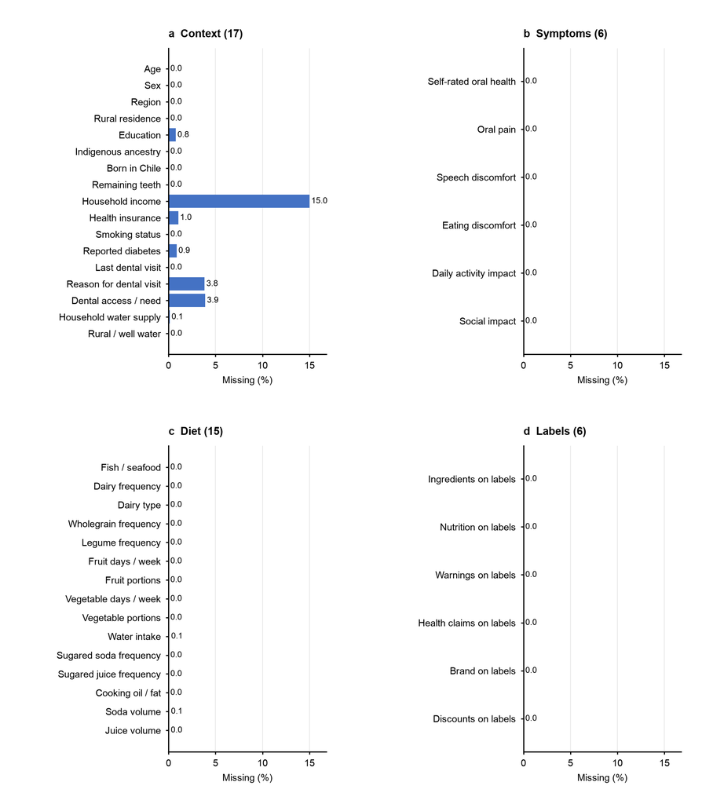

Observed predictor missingness in the 5,036-person analytical cohort, before any statistical imputation. All 44 predictors are shown by predefined block. Structural categories and confirmed nonconsumption have already been resolved; zero bars denote fully observed derived predictors. Numbers are unweighted percentages rounded to one decimal place; a displayed 0.0 may represent a very small nonzero proportion. No participant is excluded because of these missing predictors.

Missingness across all 44 constructs.

| variable | Description | n | missing | percent_missing |
| --- | --- | --- | --- | --- |
| age | Age at survey | 5036 | 0 | 0.00 |
| sex | Recorded sex | 5036 | 0 | 0.00 |
| region | Survey region (2016 boundaries) | 5036 | 0 | 0.00 |
| rural | Urban/rural residence | 5036 | 0 | 0.00 |
| education | Low <8, intermediate 8–12, high >=13 years of schooling | 5036 | 38 | 0.75 |
| indigenous | Self-reported membership/ancestry of a recognized indigenous people | 5036 | 0 | 0.00 |
| born_chile | Born in Chile | 5036 | 0 | 0.00 |
| teeth_remaining | Total remaining teeth, upper plus lower jaw | 5036 | 0 | 0.00 |
| income_band | Monthly net income of the entire household, in questionnaire bands | 5036 | 755 | 14.99 |
| health_insurance | Participant's health insurance system, including public insurance group | 5036 | 52 | 1.03 |
| smoking_status | Self-reported current daily, occasional, former or never cigarette smoking | 5036 | 0 | 0.00 |
| diabetes_reported | Ever told by a health professional that the participant had diabetes | 5036 | 43 | 0.85 |
| dental_visit | Time since last dental visit; potentially responsive to existing disease or treatment | 5036 | 0 | 0.00 |
| dental_visit_reason | Main reason for the most recent dental visit | 5036 | 193 | 3.83 |
| dental_access | Dental care received or unmet need during the previous six months | 5036 | 196 | 3.89 |
| household_water_source | Household supply: public network vs other; not a measure of fluoride exposure | 5036 | 6 | 0.12 |
| rural_water_consumption | Consumed well, spring or rural drinking water during the previous week for drinking/cooking; not bottled water or fluoride concentration | 5036 | 1 | 0.02 |
| oral_health_selfrating | Overall self-rated oral health | 5036 | 0 | 0.00 |
| oral_pain | Frequency of suffering or pain attributed to teeth or dentures | 5036 | 0 | 0.00 |
| oral_speech | Frequency of discomfort from teeth or dentures when speaking | 5036 | 0 | 0.00 |
| oral_eating | Frequency of discomfort from teeth or dentures when eating | 5036 | 0 | 0.00 |
| oral_daily_activities | Frequency of interference with daily activities from teeth or dentures | 5036 | 0 | 0.00 |
| oral_social | Frequency of interference with social relationships from teeth or dentures | 5036 | 0 | 0.00 |
| fish | Fish/seafood consumption frequency | 5036 | 0 | 0.00 |
| dairy_frequency | Dairy consumption frequency | 5036 | 0 | 0.00 |
| dairy_type | Usual dairy fat content, with structural category for nonconsumers | 5036 | 0 | 0.00 |
| wholegrain | Wholegrain consumption frequency | 5036 | 0 | 0.00 |
| legumes | Legume consumption frequency | 5036 | 0 | 0.00 |
| fruit_days | Fruit consumption days in a typical week | 5036 | 0 | 0.00 |
| fruit_portions | Fruit portions on a consumption day; zero for nonconsumers | 5036 | 0 | 0.00 |
| vegetable_days | Vegetable consumption days in a typical week | 5036 | 0 | 0.00 |
| vegetable_portions | Vegetable portions on a consumption day; zero for nonconsumers | 5036 | 0 | 0.00 |
| water | Self-reported glasses of water per day; water source/fluoride exposure not identified | 5036 | 4 | 0.08 |
| soda_frequency | Sugar-sweetened soda consumption frequency converted to times/day | 5036 | 0 | 0.00 |
| juice_frequency | Sugar-sweetened juice consumption frequency converted to times/day | 5036 | 0 | 0.00 |
| oil | Most frequently used cooking oil/fat | 5036 | 0 | 0.00 |
| soda_glasses_daily | Estimated daily soda volume in glasses; extreme reported values retained and audited | 5036 | 3 | 0.06 |
| juice_glasses_daily | Estimated daily juice volume in glasses; extreme reported values retained and audited | 5036 | 2 | 0.04 |
| label_ingredients | Frequency of checking/considering package ingredients | 5036 | 0 | 0.00 |
| label_nutrition | Frequency of checking/considering package nutrition | 5036 | 0 | 0.00 |
| label_warnings | Frequency of checking/considering package warnings | 5036 | 0 | 0.00 |
| label_health | Frequency of checking/considering package health | 5036 | 0 | 0.00 |
| label_brand | Frequency of checking/considering package brand | 5036 | 0 | 0.00 |
| label_discounts | Frequency of checking/considering package discounts | 5036 | 0 | 0.00 |

No participant is removed because a predictor is missing.

Source dictionary and deterministic derivations.

| variable | description | raw_variables | units | missing_and_derivation_rule |
| --- | --- | --- | --- | --- |
| age | Age at survey | Edad | years | Negative special codes and nonfinite values become missing. Missing values retained; categorical codes mapped without imposing linear spacing. |
| sex | Recorded sex | Sexo | category | Negative special codes and nonfinite values become missing. Missing values retained; categorical codes mapped without imposing linear spacing. |
| region | Survey region (2016 boundaries) | Region | category | Negative special codes and nonfinite values become missing. Missing values retained; categorical codes mapped without imposing linear spacing. |
| rural | Urban/rural residence | Zona | category | Negative special codes and nonfinite values become missing. Missing values retained; categorical codes mapped without imposing linear spacing. |
| education | Low <8, intermediate 8–12, high >=13 years of schooling | NEDU1_MINSAL_1 | category | Negative special codes and nonfinite values become missing. Missing values retained; categorical codes mapped without imposing linear spacing. |
| indigenous | Self-reported membership/ancestry of a recognized indigenous people | c6 | category | Negative special codes and nonfinite values become missing. Missing values retained; categorical codes mapped without imposing linear spacing. |
| born_chile | Born in Chile | c1 | category | Negative special codes and nonfinite values become missing. Missing values retained; categorical codes mapped without imposing linear spacing. |
| teeth_remaining | Total remaining teeth, upper plus lower jaw | m5p3 + m5p6 | teeth | Negative special codes and nonfinite values become missing. Add both jaw counts only if both observed; each jaw must be integer 0–16. |
| income_band | Monthly net income of the entire household, in questionnaire bands | as27 + as28 | household CLP/month, category | Negative special codes and nonfinite values are missing. Use nonnegative as27 in CLP/month and the ten fixed lower bounds; otherwise use as28 codes 1–11. Bounds are left-inclusive, including 1,573,000… |
| health_insurance | Participant's health insurance system, including public insurance group | as5_1 | category | Negative special codes and nonfinite values are missing. Preserve categories and unexplained missingness; no fitted transformation. |
| smoking_status | Self-reported current daily, occasional, former or never cigarette smoking | ta3 | category | Negative special codes and nonfinite values are missing. Preserve categories and unexplained missingness; no fitted transformation. |
| diabetes_reported | Ever told by a health professional that the participant had diabetes | di3 | category | Negative special codes and nonfinite values are missing. di3=3 (does not remember) is missing, although its numeric code is positive. |
| dental_visit | Time since last dental visit; potentially responsive to existing disease or treatment | sb2 | category | Negative special codes and nonfinite values become missing. Missing values retained; categorical codes mapped without imposing linear spacing. |
| dental_visit_reason | Main reason for the most recent dental visit | sb2 + sb3 | category | Negative special codes and nonfinite values are missing. sb2=6 establishes structural 'Never visited'; otherwise unknown/missing sb3 stays missing. A substantive sb3 response with sb2=6 is an inconsis… |
| dental_access | Dental care received or unmet need during the previous six months | sb4 | category | Negative special codes and nonfinite values are missing. All three negative special codes, including -7777 (not applicable), remain missing; do not interpret missing as no care. |
| household_water_source | Household supply: public network vs other; not a measure of fluoride exposure | as29 | category | Negative special codes and nonfinite values become missing. Missing values retained; categorical codes mapped without imposing linear spacing. |
| rural_water_consumption | Consumed well, spring or rural drinking water during the previous week for drinking/cooking; not bottled water or fluoride concentration | m8p13 | category | Negative special codes and nonfinite values become missing. Missing values retained; categorical codes mapped without imposing linear spacing. |
| oral_health_selfrating | Overall self-rated oral health | sb1 | category | Negative special codes and nonfinite values are missing. Preserve categories and unexplained missingness; no fitted transformation. |
| oral_pain | Frequency of suffering or pain attributed to teeth or dentures | sb5_2 | category | Negative special codes and nonfinite values are missing. Preserve categories and unexplained missingness; no fitted transformation. |
| oral_speech | Frequency of discomfort from teeth or dentures when speaking | sb5_1 | category | Negative special codes and nonfinite values are missing. Preserve categories and unexplained missingness; no fitted transformation. |
| oral_eating | Frequency of discomfort from teeth or dentures when eating | sb5_3 | category | Negative special codes and nonfinite values are missing. Preserve categories and unexplained missingness; no fitted transformation. |
| oral_daily_activities | Frequency of interference with daily activities from teeth or dentures | sb5_4 | category | Negative special codes and nonfinite values are missing. Preserve categories and unexplained missingness; no fitted transformation. |
| oral_social | Frequency of interference with social relationships from teeth or dentures | sb5_5 | category | Negative special codes and nonfinite values are missing. Preserve categories and unexplained missingness; no fitted transformation. |
| fish | Fish/seafood consumption frequency | die1a | category | Negative special codes and nonfinite values become missing. Missing values retained; categorical codes mapped without imposing linear spacing. |
| dairy_frequency | Dairy consumption frequency | die2 | category | Negative special codes and nonfinite values become missing. Missing values retained; categorical codes mapped without imposing linear spacing. |
| dairy_type | Usual dairy fat content, with structural category for nonconsumers | die2 + die3 | category | Negative special codes and nonfinite values become missing. If die2=7 set 'No dairy'; otherwise missing die3 remains missing. |
| wholegrain | Wholegrain consumption frequency | die4 | category | Negative special codes and nonfinite values become missing. Missing values retained; categorical codes mapped without imposing linear spacing. |
| legumes | Legume consumption frequency | die5 | category | Negative special codes and nonfinite values become missing. Missing values retained; categorical codes mapped without imposing linear spacing. |
| fruit_days | Fruit consumption days in a typical week | die6 | days/week | Negative special codes and nonfinite values become missing. Missing values retained; categorical codes mapped without imposing linear spacing. |
| fruit_portions | Fruit portions on a consumption day; zero for nonconsumers | die6 + die7 | portions/consumption day | Negative special codes and nonfinite values become missing. If die6=0 set 0; otherwise preserve missing die7. Do not clip large values. |
| vegetable_days | Vegetable consumption days in a typical week | die8 | days/week | Negative special codes and nonfinite values become missing. Missing values retained; categorical codes mapped without imposing linear spacing. |
| vegetable_portions | Vegetable portions on a consumption day; zero for nonconsumers | die8 + die9 | portions/consumption day | Negative special codes and nonfinite values become missing. If die8=0 set 0; otherwise preserve missing die9. Do not clip large values. |
| water | Self-reported glasses of water per day; water source/fluoride exposure not identified | die11 | glasses/day | Negative special codes and nonfinite values become missing. Preserve 0–50 glasses; code 51='other value, specify' is unquantified and missing; no clipping. |
| soda_frequency | Sugar-sweetened soda consumption frequency converted to times/day | die12_cantidad + die12_unidad | times/day | Negative special codes and nonfinite values become missing. Quantity / (1,7,30) for unit (1,2,3); unit4 nonconsumer=0, unknown/missing unit remains missing. |
| juice_frequency | Sugar-sweetened juice consumption frequency converted to times/day | die13_cantidad + die13_unidad | times/day | Negative special codes and nonfinite values become missing. Quantity / (1,7,30) for unit (1,2,3); unit4 nonconsumer=0, unknown/missing unit remains missing. |
| oil | Most frequently used cooking oil/fat | die14 | category | Negative special codes and nonfinite values become missing. Missing values retained; categorical codes mapped without imposing linear spacing. |
| soda_glasses_daily | Estimated daily soda volume in glasses; extreme reported values retained and audited | die12_cantidad + die12_unidad + die12e | glasses/day | Negative special codes and nonfinite values become missing. Daily frequency * die12e; nonconsumer=0 even if glasses/occasion missing; no clipping. |
| juice_glasses_daily | Estimated daily juice volume in glasses; extreme reported values retained and audited | die13_cantidad + die13_unidad + die13e | glasses/day | Negative special codes and nonfinite values become missing. Daily frequency * die13e; nonconsumer=0 even if glasses/occasion missing; no clipping. |
| label_ingredients | Frequency of checking/considering package ingredients | die10_a | category | Negative special codes and nonfinite values become missing. Missing values retained; categorical codes mapped without imposing linear spacing. |
| label_nutrition | Frequency of checking/considering package nutrition | die10_b | category | Negative special codes and nonfinite values become missing. Missing values retained; categorical codes mapped without imposing linear spacing. |
| label_warnings | Frequency of checking/considering package warnings | die10_c | category | Negative special codes and nonfinite values become missing. Missing values retained; categorical codes mapped without imposing linear spacing. |
| label_health | Frequency of checking/considering package health | die10_d | category | Negative special codes and nonfinite values become missing. Missing values retained; categorical codes mapped without imposing linear spacing. |
| label_brand | Frequency of checking/considering package brand | die10_e | category | Negative special codes and nonfinite values become missing. Missing values retained; categorical codes mapped without imposing linear spacing. |
| label_discounts | Frequency of checking/considering package discounts | die10_f | category | Negative special codes and nonfinite values become missing. Missing values retained; categorical codes mapped without imposing linear spacing. |

All categorical variables retain named categories. Full Spanish source/value labels and English mappings are retained in the unchanged variable_dictionary.csv. Three descriptions are adapted here to their current analytical roles: dental_visit belongs to C17, and soda_glasses_daily and juice_glasses_daily belong to D15. Earlier dictionary wording described these as sensitivity or ancillary exposures.

### 10.2 Complete participant profile

All 44 constructs by caries status and overall.

| domain | variable | level | n | observed_n | missing_n | estimate | ci_low | ci_high | units |
| --- | --- | --- | --- | --- | --- | --- | --- | --- | --- |
| No caries | age | Mean | 2347 | 2347 | 0 | 39.72 | 38.51 | 40.92 | years |
| No caries | age | Missing | 0 | 2347 | 0 | — | — | — | years |
| Caries | age | Mean | 2689 | 2689 | 0 | 43.38 | 42.44 | 44.32 | years |
| Caries | age | Missing | 0 | 2689 | 0 | — | — | — | years |
| Total | age | Mean | 5036 | 5036 | 0 | 41.72 | 40.92 | 42.51 | years |
| Total | age | Missing | 0 | 5036 | 0 | — | — | — | years |
| No caries | sex | Female | 1546 | 2347 | 0 | 53.97 | 50.12 | 57.78 | percent |
| No caries | sex | Male | 801 | 2347 | 0 | 46.03 | 42.22 | 49.88 | percent |
| No caries | sex | Missing | 0 | 2347 | 0 | — | — | — | percent |
| Caries | sex | Female | 1579 | 2689 | 0 | 46.27 | 43.04 | 49.53 | percent |
| Caries | sex | Male | 1110 | 2689 | 0 | 53.73 | 50.47 | 56.96 | percent |
| Caries | sex | Missing | 0 | 2689 | 0 | — | — | — | percent |
| Total | sex | Female | 3125 | 5036 | 0 | 49.76 | 47.39 | 52.13 | percent |
| Total | sex | Male | 1911 | 5036 | 0 | 50.24 | 47.87 | 52.61 | percent |
| Total | sex | Missing | 0 | 5036 | 0 | — | — | — | percent |
| No caries | region | 01 Arica and Parinacota | 154 | 2347 | 0 | 1.40 | 1.13 | 1.74 | percent |
| No caries | region | 02 Tarapaca | 150 | 2347 | 0 | 2.17 | 1.66 | 2.84 | percent |
| No caries | region | 03 Antofagasta | 133 | 2347 | 0 | 4.07 | 3.12 | 5.28 | percent |
| No caries | region | 04 Atacama | 140 | 2347 | 0 | 1.96 | 1.31 | 2.91 | percent |
| No caries | region | 05 Coquimbo | 83 | 2347 | 0 | 3.74 | 2.57 | 5.39 | percent |
| No caries | region | 06 Valparaiso | 293 | 2347 | 0 | 12.63 | 10.63 | 14.93 | percent |
| No caries | region | 07 Metropolitan | 374 | 2347 | 0 | 42.33 | 37.87 | 46.92 | percent |
| No caries | region | 08 O'Higgins | 70 | 2347 | 0 | 2.82 | 1.99 | 3.98 | percent |
| No caries | region | 09 Maule | 117 | 2347 | 0 | 5.96 | 3.88 | 9.05 | percent |
| No caries | region | 10 Biobio | 231 | 2347 | 0 | 10.13 | 8.21 | 12.43 | percent |
| No caries | region | 11 La Araucania | 102 | 2347 | 0 | 5.33 | 4.02 | 7.04 | percent |
| No caries | region | 12 Los Rios | 112 | 2347 | 0 | 1.84 | 1.40 | 2.41 | percent |
| No caries | region | 13 Los Lagos | 97 | 2347 | 0 | 3.83 | 2.74 | 5.33 | percent |
| No caries | region | 14 Aysen | 162 | 2347 | 0 | 0.73 | 0.59 | 0.91 | percent |
| No caries | region | 15 Magallanes and Antarctica | 129 | 2347 | 0 | 1.08 | 0.84 | 1.38 | percent |

[output cut: 621 more lines]

Counts and missingness are unweighted. Category estimates are weighted percentages among observed responses; numeric estimates are weighted means in the stated units. Missing rows carry counts only. Intervals at category boundaries may be unidentifiable.

### 10.3 Context, oral status and full calibration

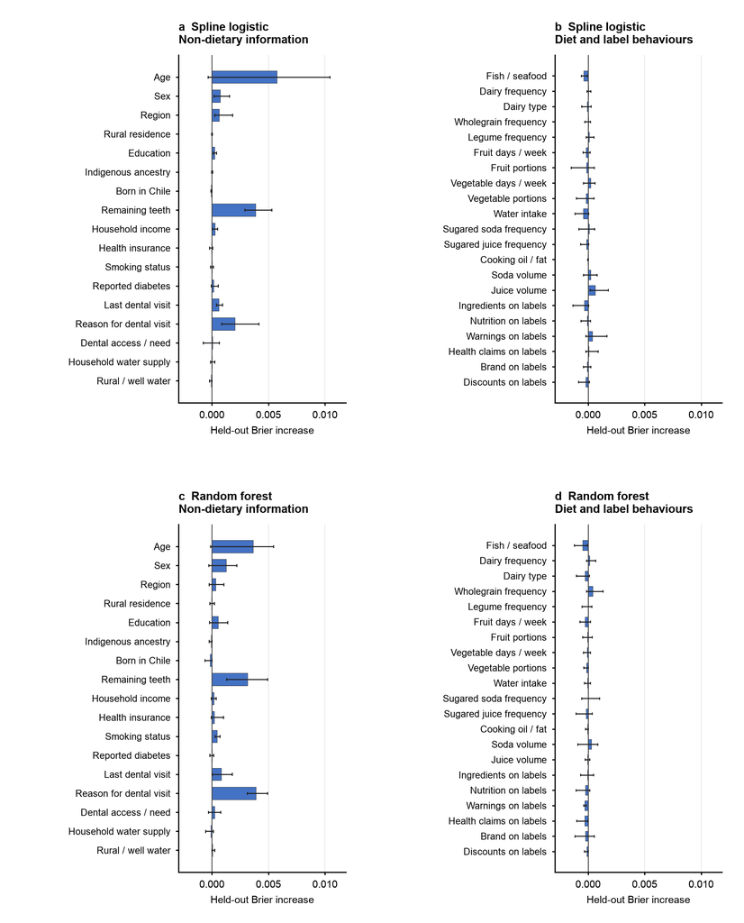

Complete individual contributions for the 38-predictor context scenario. Every predictor appears once per model. Columns divide the display into non-dietary and diet/label information without changing the fitted models. Signed bars are weighted fold-mean Brier increases; whiskers are minimum–maximum fold means, not confidence intervals. Five held-out permutations per predictor and fold are used; shared scales retain negative values. These are marginal, model-specific reliance measures.

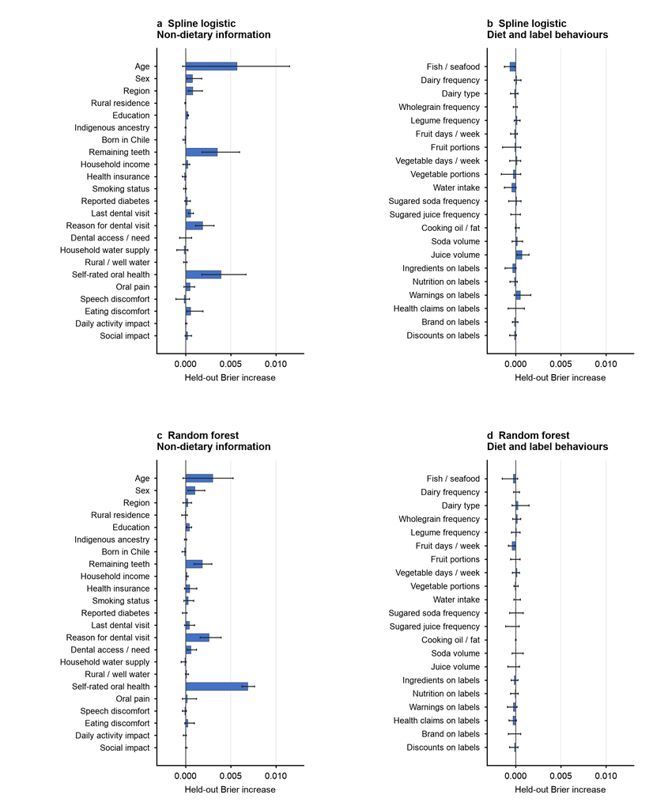

Complete individual contributions for the symptom-aware 44-predictor scenario. Every predictor appears once per model. Columns divide the display into non-dietary and diet/label information without changing the fitted models. Signed bars are weighted fold-mean Brier increases; whiskers are minimum–maximum fold means, not confidence intervals. Five held-out permutations per predictor and fold are used; shared scales retain negative values. These are marginal, model-specific reliance measures.

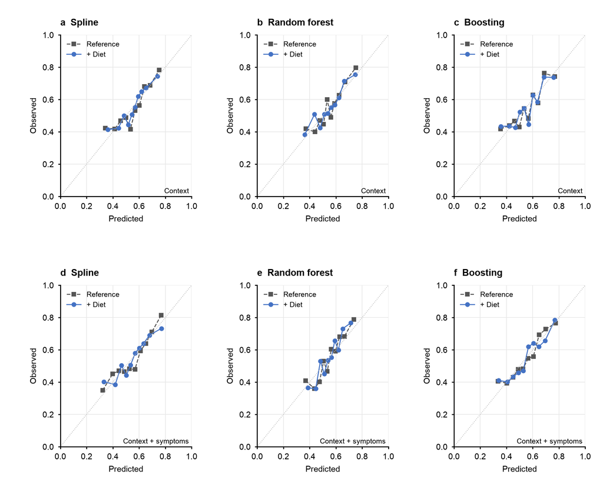

Held-out calibration summaries for the three model families without and with direct dietary indicators. The first row uses context references; the second adds oral-status indicators. Points are survey-weighted observed proportions in prediction-quantile bins. Lines connect bin summaries and have no confidence intervals; the dotted diagonal marks perfect calibration.

### 10.4 Selected parameters, folds and descriptive thresholds

Selected outer-training fits and beverage sensitivity caps.

| Model | fold | n_train | n_test | selected_params | converged | beverage_training_caps |
| --- | --- | --- | --- | --- | --- | --- |
| Spline logistic: B8 | 1 | 4030 | 1006 | {"C": 0.01} | True | {} |
| Spline logistic: B8 | 2 | 4029 | 1007 | {"C": 0.1} | True | {} |
| Spline logistic: B8 | 3 | 4025 | 1011 | {"C": 0.1} | True | {} |
| Spline logistic: B8 | 4 | 4029 | 1007 | {"C": 0.01} | True | {} |
| Spline logistic: B8 | 5 | 4031 | 1005 | {"C": 0.01} | True | {} |
| Spline logistic: C17 | 1 | 4030 | 1006 | {"C": 0.01} | True | {} |
| Spline logistic: C17 | 2 | 4029 | 1007 | {"C": 0.01} | True | {} |
| Spline logistic: C17 | 3 | 4025 | 1011 | {"C": 0.01} | True | {} |
| Spline logistic: C17 | 4 | 4029 | 1007 | {"C": 0.01} | True | {} |
| Spline logistic: C17 | 5 | 4031 | 1005 | {"C": 0.01} | True | {} |
| Spline logistic: C17+D15 | 1 | 4030 | 1006 | {"C": 0.01} | True | {} |
| Spline logistic: C17+D15 | 2 | 4029 | 1007 | {"C": 0.001} | True | {} |
| Spline logistic: C17+D15 | 3 | 4025 | 1011 | {"C": 0.001} | True | {} |
| Spline logistic: C17+D15 | 4 | 4029 | 1007 | {"C": 0.001} | True | {} |
| Spline logistic: C17+D15 | 5 | 4031 | 1005 | {"C": 0.01} | True | {} |
| Spline logistic: C17+D15+L6 | 1 | 4030 | 1006 | {"C": 0.001} | True | {} |
| Spline logistic: C17+D15+L6 | 2 | 4029 | 1007 | {"C": 0.001} | True | {} |
| Spline logistic: C17+D15+L6 | 3 | 4025 | 1011 | {"C": 0.001} | True | {} |
| Spline logistic: C17+D15+L6 | 4 | 4029 | 1007 | {"C": 0.001} | True | {} |
| Spline logistic: C17+D15+L6 | 5 | 4031 | 1005 | {"C": 0.01} | True | {} |
| Spline logistic: C17+S6 | 1 | 4030 | 1006 | {"C": 0.01} | True | {} |
| Spline logistic: C17+S6 | 2 | 4029 | 1007 | {"C": 0.01} | True | {} |
| Spline logistic: C17+S6 | 3 | 4025 | 1011 | {"C": 0.01} | True | {} |
| Spline logistic: C17+S6 | 4 | 4029 | 1007 | {"C": 0.01} | True | {} |
| Spline logistic: C17+S6 | 5 | 4031 | 1005 | {"C": 0.01} | True | {} |
| Spline logistic: C17+S6+D15 | 1 | 4030 | 1006 | {"C": 0.01} | True | {} |
| Spline logistic: C17+S6+D15 | 2 | 4029 | 1007 | {"C": 0.01} | True | {} |
| Spline logistic: C17+S6+D15 | 3 | 4025 | 1011 | {"C": 0.001} | True | {} |
| Spline logistic: C17+S6+D15 | 4 | 4029 | 1007 | {"C": 0.001} | True | {} |
| Spline logistic: C17+S6+D15 | 5 | 4031 | 1005 | {"C": 0.01} | True | {} |

[output cut: 85 more lines]

Each selected parameter set came from inner validation. Empty cap dictionaries identify the uncapped primary variants. A missing cap inside a sensitivity dictionary means no positive training observations were available.

PSU separation and validation counts.

| level | outer_fold | inner_fold | n_train | n_test | psu_train | psu_test | psu_overlap | n_events_train | n_events_test |
| --- | --- | --- | --- | --- | --- | --- | --- | --- | --- |
| outer | 1 | — | 4030 | 1006 | 860 | 212 | 0 | 2152 | 537 |
| inner | 1 | 1.0 | 2689 | 1341 | 577 | 283 | 0 | 1436 | 716 |
| inner | 1 | 2.0 | 2685 | 1345 | 569 | 291 | 0 | 1435 | 717 |
| inner | 1 | 3.0 | 2686 | 1344 | 574 | 286 | 0 | 1433 | 719 |
| outer | 2 | — | 4029 | 1007 | 853 | 219 | 0 | 2151 | 538 |
| inner | 2 | 1.0 | 2686 | 1343 | 571 | 282 | 0 | 1435 | 716 |
| inner | 2 | 2.0 | 2688 | 1341 | 559 | 294 | 0 | 1435 | 716 |
| inner | 2 | 3.0 | 2684 | 1345 | 576 | 277 | 0 | 1432 | 719 |
| outer | 3 | — | 4025 | 1011 | 861 | 211 | 0 | 2149 | 540 |
| inner | 3 | 1.0 | 2684 | 1341 | 567 | 294 | 0 | 1433 | 716 |
| inner | 3 | 2.0 | 2682 | 1343 | 572 | 289 | 0 | 1432 | 717 |
| inner | 3 | 3.0 | 2684 | 1341 | 583 | 278 | 0 | 1433 | 716 |
| outer | 4 | — | 4029 | 1007 | 856 | 216 | 0 | 2151 | 538 |
| inner | 4 | 1.0 | 2683 | 1346 | 571 | 285 | 0 | 1433 | 718 |
| inner | 4 | 2.0 | 2686 | 1343 | 568 | 288 | 0 | 1433 | 718 |
| inner | 4 | 3.0 | 2689 | 1340 | 573 | 283 | 0 | 1436 | 715 |
| outer | 5 | — | 4031 | 1005 | 858 | 214 | 0 | 2153 | 536 |
| inner | 5 | 1.0 | 2689 | 1342 | 570 | 288 | 0 | 1437 | 716 |
| inner | 5 | 2.0 | 2684 | 1347 | 578 | 280 | 0 | 1432 | 721 |
| inner | 5 | 3.0 | 2689 | 1342 | 568 | 290 | 0 | 1437 | 716 |

Every outer and inner split must have zero PSU overlap. No participant-level IDs or probabilities are shown.

Descriptive classification at probability 0.5.

| Model | Sensitivity | Specificity | PPV | Accuracy |
| --- | --- | --- | --- | --- |
| Spline logistic: B8 | 0.710 | 0.415 | 0.594 | 0.576 |
| Random forest: B8 | 0.688 | 0.420 | 0.588 | 0.566 |
| Histogram boosting: B8 | 0.688 | 0.431 | 0.593 | 0.571 |
| Spline logistic: C17 | 0.699 | 0.450 | 0.605 | 0.586 |
| Random forest: C17 | 0.712 | 0.472 | 0.619 | 0.603 |
| Histogram boosting: C17 | 0.688 | 0.473 | 0.611 | 0.591 |
| Spline logistic: C17+D15 | 0.731 | 0.393 | 0.592 | 0.578 |
| Random forest: C17+D15 | 0.715 | 0.443 | 0.607 | 0.592 |
| Histogram boosting: C17+D15 | 0.694 | 0.481 | 0.617 | 0.597 |
| Spline logistic: C17+D15+L6 | 0.734 | 0.398 | 0.595 | 0.582 |
| Random forest: C17+D15+L6 | 0.731 | 0.417 | 0.602 | 0.589 |
| Histogram boosting: C17+D15+L6 | 0.683 | 0.451 | 0.600 | 0.578 |
| Spline logistic: C17+S6 | 0.690 | 0.489 | 0.619 | 0.599 |
| Random forest: C17+S6 | 0.740 | 0.482 | 0.632 | 0.623 |
| Histogram boosting: C17+S6 | 0.694 | 0.488 | 0.620 | 0.601 |
| Spline logistic: C17+S6+D15 | 0.708 | 0.467 | 0.615 | 0.599 |
| Random forest: C17+S6+D15 | 0.732 | 0.455 | 0.618 | 0.606 |
| Histogram boosting: C17+S6+D15 | 0.695 | 0.489 | 0.621 | 0.602 |
| Spline logistic: C17+S6+D15+L6 | 0.717 | 0.451 | 0.611 | 0.596 |
| Random forest: C17+S6+D15+L6 | 0.733 | 0.443 | 0.613 | 0.601 |
| Histogram boosting: C17+S6+D15+L6 | 0.696 | 0.495 | 0.624 | 0.605 |

The threshold was not optimized and is not a proposed clinical decision rule. Probability metrics lead the main analysis.

Weighted and unweighted evaluation.

| Model | Weighted AUC | Unweighted AUC | Weighted Brier | Unweighted Brier |
| --- | --- | --- | --- | --- |
| Spline logistic: B8 | 0.618 | 0.632 | 0.2380 | 0.2366 |
| Random forest: B8 | 0.601 | 0.622 | 0.2407 | 0.2386 |
| Histogram boosting: B8 | 0.615 | 0.624 | 0.2380 | 0.2378 |
| Spline logistic: C17 | 0.637 | 0.652 | 0.2335 | 0.2320 |
| Random forest: C17 | 0.640 | 0.643 | 0.2324 | 0.2339 |
| Histogram boosting: C17 | 0.630 | 0.645 | 0.2351 | 0.2335 |
| Spline logistic: C17+D15 | 0.623 | 0.634 | 0.2379 | 0.2369 |
| Random forest: C17+D15 | 0.625 | 0.634 | 0.2361 | 0.2357 |
| Histogram boosting: C17+D15 | 0.623 | 0.640 | 0.2368 | 0.2344 |
| Spline logistic: C17+D15+L6 | 0.618 | 0.630 | 0.2383 | 0.2375 |
| Random forest: C17+D15+L6 | 0.614 | 0.630 | 0.2375 | 0.2365 |
| Histogram boosting: C17+D15+L6 | 0.612 | 0.636 | 0.2391 | 0.2351 |
| Spline logistic: C17+S6 | 0.654 | 0.662 | 0.2298 | 0.2296 |
| Random forest: C17+S6 | 0.654 | 0.651 | 0.2310 | 0.2330 |
| Histogram boosting: C17+S6 | 0.647 | 0.655 | 0.2317 | 0.2314 |
| Spline logistic: C17+S6+D15 | 0.633 | 0.641 | 0.2352 | 0.2348 |
| Random forest: C17+S6+D15 | 0.653 | 0.649 | 0.2315 | 0.2336 |
| Histogram boosting: C17+S6+D15 | 0.641 | 0.649 | 0.2331 | 0.2324 |
| Spline logistic: C17+S6+D15+L6 | 0.630 | 0.640 | 0.2360 | 0.2351 |
| Random forest: C17+S6+D15+L6 | 0.637 | 0.641 | 0.2341 | 0.2348 |
| Histogram boosting: C17+S6+D15+L6 | 0.635 | 0.648 | 0.2347 | 0.2329 |

Both evaluate the same survey-weighted fitted models. Unweighted estimates are secondary diagnostics and receive no survey-bootstrap intervals.

### 10.5 Reproducibility record

Verified analysis record.

| Record | Value |
| --- | --- |
| Run completed (UTC) | 2026-09-10T19:52:48.138176+00:00 |
| Eligible participants / events | 5036 / 2689 |
| Fitted variants / benchmark | 23 / 1 |
| Outer / inner folds | 5 / 3, PSU-grouped |
| Valid paired probability-score replicates | 1000 |
| SAV SHA-256 | 9873b421d446190070bfff6495321fb152485c47457692936dbcd18c542eb89a |
| Pre-fit plan SHA-256 | 95c5aac1f98b7fc3c02d4df7f9566a88517d8ccf7a82566072851a3d423ae328 |
| Software | {"numpy": "2.5.3", "pandas": "3.0.5", "scipy": "1.18.1", "sklearn": "1.9.0"} |
| Scope | Independent dietary incremental-value proposal; previous Andrea revision is separate |

Rendering stops if analysis code, the pre-fit plan, input provenance, model manifests, cohort sizes or validation checks are inconsistent. The report reads aggregate tables only.

The analysis plan records the hypothesis, design choices, limitations and checked background sources. The executable runner is `scripts/run_dietary.py`; aggregate outputs live in `outputs/dietary/tables` and figure exports in `outputs/dietary/figures`. Held-out participant probabilities, folds and caches remain private. This report and its new results are independent of the preserved Andrea manuscript correction and earlier model estimates.